# BIOSTAT702 R Tutorial 1:

Descriptive Presentation of Variables

Marissa Ashner, PhD

Last Updated: 2024-08-05

This tutorial will follow closely with Chapter 3 in the [textbook](https://bookdown.org/rwnahhas/RMPH/datasumm.html).

# Packages

The following code loads the packages you need for the tutorial.

```r
## NOTE: If you do not have a package installed, you must install it first
# For example, you can run the following code if you don't have the gtsummary package:
# install.packages("gtsummary")


# for navigating within the R project
library(here)

# for data wrangling
library(tidyverse)

# for creating table 1
library(gtsummary)
library(table1)
library(tableone)
library(labelled)

# for exporting table 1
library(flextable)
library(gt)
```

# Resources

Below is a list of resources that may be helpful or provide more information on this topic.

- [R Charts – Super cool website for plotting in R using ggplot and base R](https://r-charts.com/)
- [R Graph Gallery – Another super cool website for ploting in R, focusing on ggplot/tidyverse](https://r-graph-gallery.com/)
- [Helpful vignette for the table1 package](https://cran.r-project.org/web/packages/table1/vignettes/table1-examples.html)
- [Vignette for tableone package](https://rstudio-pubs-static.s3.amazonaws.com/13321_da314633db924dc78986a850813a50d5.html)

# Note about syntax

In this set of tutorials, I will at times use “piping” to chain together operations in R. I will use the `%>%` pipe operator from the `magrittr` package that is also imported by the `dplyr` package. Some of you may be more familiar with the `|>` pipe operator, which is now a native feature of the R language. They both do the same thing.

Additionally, I will be doing most of the data visualization using the `ggplot2` package. The textbook uses base R more frequently for data visualization and again, both are fine; it’s a matter of personal preference.

# Load Data

```r
# Load Data
# will be called "nhanes_adult_exam_sub" in your environment
load(here("data/nhanes1718_adult_exam_sub_rmph.Rdata"))

# rename dataset for convenience
nhanes <- nhanes_adult_exam_sub
```

# Examining the Data

## Numerically

The first thing you want to do with a dataset before analyzing it is examine all the variables you will be using. You want to look at the distributions and formats of your variables, as well as check for unreasonable values and missing values.

### str()

The `str()` function will display the dimensions of the data frame, as well as the structure of each variable. We are just showing the first 10 variables, for brevity.

```r
str(nhanes[,1:10])
```

```
## 'data.frame':    1000 obs. of  10 variables:
##  $ RIAGENDR: Factor w/ 2 levels "Male","Female": 1 2 2 2 2 1 1 1 2 2 ...
##  $ RIDAGEYR: num  59 55 64 26 54 61 23 55 23 80 ...
##  $ RIDRETH3: Factor w/ 6 levels "Mexican American",..: 3 3 6 3 3 3 2 3 3 3 ...
##  $ DMDEDUC2: Factor w/ 5 levels "< 9","9-11","HS/GED",..: 4 3 3 4 4 3 4 3 3 3 ...
##  $ URXCRS  : num  11315 14586 15116 3801 7779 ...
##  $ ALQ130  : num  1 0 0 4 2 0 4 4 2 1 ...
##  $ ALQ151  : Factor w/ 2 levels "Yes","No": 2 2 1 2 2 2 2 1 2 2 ...
##  $ BMXWT   : num  94.8 71.4 45.4 180.9 53.4 ...
##  $ BMXHT   : num  175 156 155 166 166 ...
##  $ BMXBMI  : num  31.1 29.5 19 65.3 19.5 31.3 25 22.5 14.8 33.3 ...
```

### summary()

The `summary()` function will display some basic descriptive statistics for each of the variables in the dataset, as shown below, including the number of missing values.

```r
summary(nhanes[,1:10])
```

```
##    RIAGENDR      RIDAGEYR                   RIDRETH3              DMDEDUC2
##  Male  :482   Min.   :20.00   Mexican American  : 96   < 9            : 41
##  Female:518   1st Qu.:32.00   Other Hispanic    : 92   9-11           : 75
##               Median :47.00   Non-Hispanic White:624   HS/GED         :266
##               Mean   :47.72   Non-Hispanic Black: 87   Some college/AA:324
##               3rd Qu.:61.00   Non-Hispanic Asian: 61   College grad   :294
##               Max.   :80.00   Other/Multi       : 40
##
##      URXCRS            ALQ130        ALQ151        BMXWT            BMXHT
##  Min.   :  795.6   Min.   : 0.000   Yes :112   Min.   : 37.50   Min.   :141.4
##  1st Qu.: 5480.8   1st Qu.: 1.000   No  :839   1st Qu.: 69.15   1st Qu.:160.4
##  Median :10166.0   Median : 2.000   NA's: 49   Median : 82.05   Median :167.3
##  Mean   :10959.6   Mean   : 1.972              Mean   : 85.10   Mean   :167.8
##  3rd Qu.:14519.7   3rd Qu.: 3.000              3rd Qu.: 97.62   3rd Qu.:175.4
##  Max.   :50034.4   Max.   :15.000              Max.   :191.30   Max.   :195.8
##  NA's   :16        NA's   :50                  NA's   :12       NA's   :10
##      BMXBMI
##  Min.   :14.80
##  1st Qu.:25.07
##  Median :29.00
##  Mean   :30.09
##  3rd Qu.:33.83
##  Max.   :65.30
##  NA's   :12
```

### Computations of individual descriptive statistics

Rather than summarizing all the variables and statistics, you can also run functions that calculate one statistic for one (or more) variable. If there are missing values, the `na.rm = TRUE` argument is needed to remove them from the calculation.

These include (but are not limited to):

- `mean()`
- `sd()` (standard deviation)
- `median`
- `IQR`
- `quantile` (can specify quantiles)
- `min`
- `max`
- `sum(complete.cases())` (number of non-missing values)

For example:

```r
# mean of SBP variable
mean(nhanes$sbp, na.rm = TRUE)
```

```
## [1] 123.5313
```

```r
# every 10th percentile of the SBP variable
quantile(nhanes$sbp,
         probs = seq(0, 1, 0.1),
         na.rm = TRUE)
```

```
##   0%  10%  20%  30%  40%  50%  60%  70%  80%  90% 100%
##   83  103  108  114  117  121  126  131  137  145  234
```

```r
# how many complete cases in the SBP variable
sum(complete.cases(nhanes$sbp))
```

```
## [1] 958
```

### Tables

You can also use the `table()` (or `prop.table()`) function for categorical variables to examine the frequency and prportion of observations at each level. Typically, the option `useNA = "ifany"` is used for frequency tables.

```r
# frequency table for the income variable
table(nhanes$income, useNA = "ifany")
```

```
##
##            < $25,000 $25,000 to < $55,000             $55,000+
##                  156                  254                  480
##                 <NA>
##                  110
```

```r
# proportion table for the income variable
prop.table(table(nhanes$income, useNA = "ifany"))
```

```
##
##            < $25,000 $25,000 to < $55,000             $55,000+
##                0.156                0.254                0.480
##                 <NA>
##                0.110
```

You can also create 2-way (or 3-way) tables.

```r
# 2-way table with the income and gender variables
table(nhanes$income, nhanes$RIAGENDR, useNA = "ifany")
```

```
##
##                        Male Female
##   < $25,000              66     90
##   $25,000 to < $55,000  130    124
##   $55,000+              242    238
##   <NA>                   44     66
```

## Graphically

While there are many ways to visualize data in complex wayss, here we show common ways to visualize a single continuous or categorical variable as a way of describing the variable for the analysis team.

For continuous variables, typically a histogram is created using the `hist()` function in base R or the `geom_histogram()` function in `ggplot2`. Base R is most convenient for easy, simply plots. I recommend ggplot for anything you want to output to a wider audience.

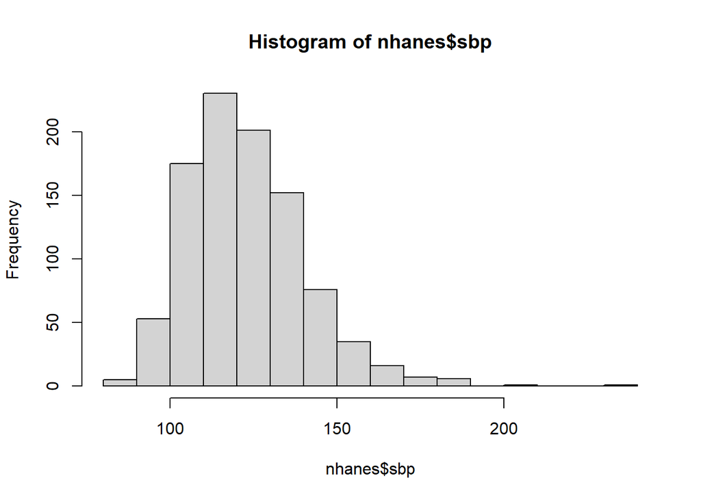

```r
# histogram for the SBP variable in base R
hist(nhanes$sbp)
```

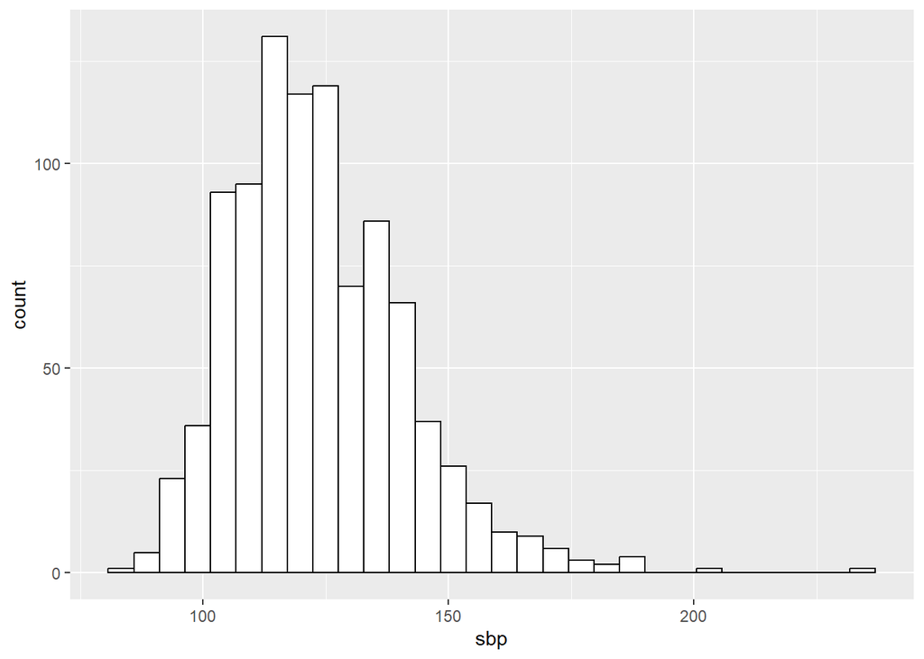

```r
# histogram for the SBP variable in ggplot
ggplot(data = nhanes) + geom_histogram(aes(x = sbp),
                                       col = "black",
                                       fill = "white")
```

For categorical or binary variable, bar charts are usually the easiest way to go. You can use the `barplot()` function in base R.

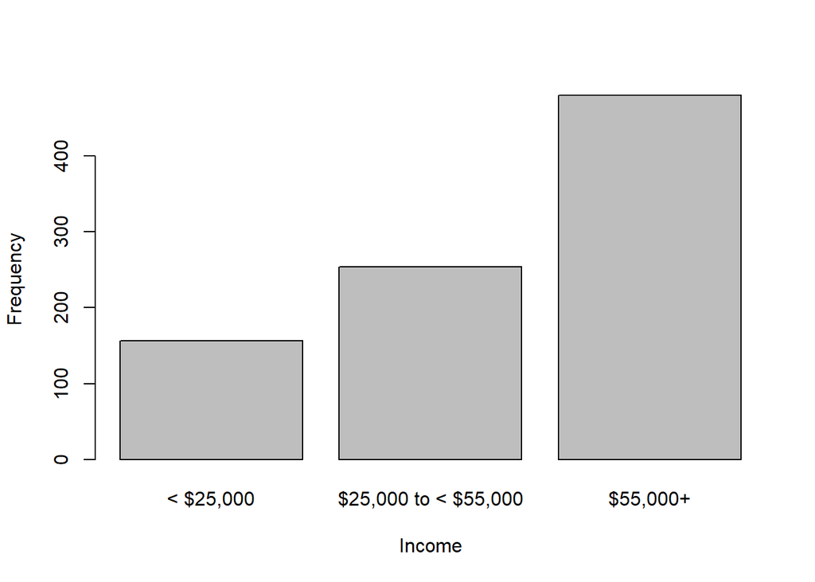

```r
# barplot for the income variable in base R
# You can also use prop.table(table()) instead of table() for plotting proportions
barplot(table(nhanes$income),
        xlab = "Income", ylab = "Frequency")
```

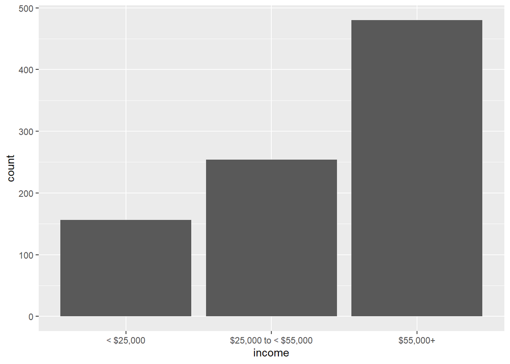

```r
# barplot for the income variable using ggplot
# remove the NAs if needed, otherwise they will show up with their own bar
ggplot(data = subset(nhanes, complete.cases(income))) +
  geom_bar(aes(x = income))
```

# Creating a Table 1 using gtsummary

In most published articles containing statistical analyses, there is a table containing descriptive statistics for the sample, typically referred to as “Table 1”. Since it’s so common, there are several packages in R that facilitate the creation of a Table 1 for you. We will focus on the one in the `gtsummary` package, as your textbook uses, but will mention other popular solutions as well.

## Overall

This method creates a table of descriptive statistics for the entire sample.

### Default Settings

```r
# Create the Overall Table 1 using gtsummary

nhanes %>%
  # Select the variables to be included in the table
  select(sbp, RIDAGEYR, RIAGENDR, income) %>%
  tbl_summary(
    # the following code can be included to override including missing values in the table:
    # missing = "no"
  )
```

| **Characteristic** | **N = 1,000**<sup>1</sup> |
| --- | --- |
| sbp | 121 (111, 134) |
| Unknown | 42 |
| RIDAGEYR | 47 (32, 61) |
| RIAGENDR |  |
| Male | 482 (48%) |
| Female | 518 (52%) |
| income |  |
| < $25,000 | 156 (18%) |
| $25,000 to < $55,000 | 254 (29%) |
| $55,000+ | 480 (54%) |
| Unknown | 110 |

<sup>1</sup> Median (IQR); n (%)

### Using the additional options in tbl_summary

There are many ways to customize your table, including which statistic is shown for each variale, how many digits to round to, etc. Below is an example customizing some of the options. You can type `?tbl_summary` into your R console to see the options.

```r
nhanes %>%
  select(sbp, RIDAGEYR, RIAGENDR, income) %>%
  subset(complete.cases(sbp, RIDAGEYR, RIAGENDR, income)) %>%
  tbl_summary(
    statistic = list(all_continuous()  ~ "{mean} ({sd})",
                     all_categorical() ~ "{n}    ({p}%)"),
    digits = list(all_continuous()  ~ c(2, 2),
                  all_categorical() ~ c(0, 1)),
    type = list(sbp      ~ "continuous",
                RIDAGEYR ~ "continuous",
                RIAGENDR ~ "categorical",
                income   ~ "categorical"),
    label  = list(sbp      ~ "SBP (mmHg)",
                  RIDAGEYR ~ "Age (years)",
                  RIAGENDR ~ "Gender",
                  income   ~ "Annual Income"),

  ) %>%
  modify_header(label = "**Variable**") %>%
  modify_caption("Participant characteristics  (complete case analysis)") %>%
  bold_labels()
```

Participant characteristics (complete case analysis)

| **Variable** | **N = 855**<sup>1</sup> |
| --- | --- |
| SBP (mmHg) | 123.57 (17.57) |
| Age (years) | 48.11 (17.43) |
| Gender |  |
| Male | 425 (49.7%) |
| Female | 430 (50.3%) |
| Annual Income |  |
| < $25,000 | 148 (17.3%) |
| $25,000 to < $55,000 | 248 (29.0%) |
| $55,000+ | 459 (53.7%) |

<sup>1</sup> Mean (SD); n (%)

## By Exposure or Outcome

It is also common to display descriptive statistics stratified by some sort of subgroup, usually either the main outcome or exposure. If the variable of interest for stratification is continuous, it is typically discretized just for the purposes of the Table 1, and used as continuous in the subsequent analyses.Below is an example of stratifying by gender.

```r
TABLE1 <- nhanes %>%
  select(sbp, RIDAGEYR, RIAGENDR, income) %>%
  subset(complete.cases(sbp, RIDAGEYR, RIAGENDR, income)) %>%
  tbl_summary(
    # The "by" variable
    by = RIAGENDR,
    statistic = list(all_continuous()  ~ "{mean} ({sd})",
                     all_categorical() ~ "{n}    ({p}%)"),
    digits = list(all_continuous()  ~ c(2, 2),
                  all_categorical() ~ c(0, 1)),
    type = list(sbp      ~ "continuous",
                RIDAGEYR ~ "continuous",
                income   ~ "categorical"),
    label  = list(sbp      ~ "SBP (mmHg)",
                  RIDAGEYR ~ "Age (years)",
                  income   ~ "Annual Income")
  ) %>%
  modify_header(
    label = "**Variable**",
    # The following adds the % to the column total label
    # <br> is the location of a line break
    all_stat_cols() ~ "**{level}**<br>N = {n} ({style_percent(p, digits=1)}%)"
  ) %>%
  modify_caption("Participant characteristics, by gender") %>%
  bold_labels()  %>%
  # Include an "overall" column
  add_overall(
    last = FALSE,
    # The ** make it bold
    col_label = "**All participants**<br>N = {N}"
  )
TABLE1
```

Participant characteristics, by gender

| **Variable** | **All participants** N = 855<sup>1</sup> | **Male** N = 425 (49.7%)<sup>1</sup> | **Female** N = 430 (50.3%)<sup>1</sup> |
| --- | --- | --- | --- |
| SBP (mmHg) | 123.57 (17.57) | 124.55 (16.01) | 122.60 (18.96) |
| Age (years) | 48.11 (17.43) | 47.26 (17.38) | 48.94 (17.45) |
| Annual Income |  |  |  |
| < $25,000 | 148 (17.3%) | 65 (15.3%) | 83 (19.3%) |
| $25,000 to < $55,000 | 248 (29.0%) | 127 (29.9%) | 121 (28.1%) |
| $55,000+ | 459 (53.7%) | 233 (54.8%) | 226 (52.6%) |

<sup>1</sup> Mean (SD); n (%)

## Exporting to an external file

It is easy to export these tables to an external file, for sharing purposes. The following code shows how to save as a word document (using the `flextable` package) or html (using the `gt` package).

```r
TABLE1 %>%
  as_flex_table() %>%
  save_as_docx(path = here("01-DescriptivePresentationOfVariables",
                           "01-gtsummaryTable1.docx"))

TABLE1 %>%
  as_gt() %>%
  gtsave(filename = here("01-DescriptivePresentationOfVariables",
                           "01-gtsummaryTable1.html"))
```

## Adding p-values to Table 1

TLDR; it is not recommended to add p-values to Table 1, but you can do it easily. Consult the textbook for more details.

# Other packages to create Table 1 in R

There are several other packages that can help to create your Table 1 in R, including `flextable`, `tableone`, and `table1`. I will show brief examples of how to use `table1`, my personal package of choice for Table 1 creation, and `tableone`.

## table1

```r
##### complete cases for nhanes table 1 #####
nhanes_table1 = nhanes %>%
  select(sbp, RIDAGEYR, RIAGENDR, income) %>%
  subset(complete.cases(sbp, RIDAGEYR, RIAGENDR, income))

##### Variable Name Labels #####
labels <- list(
  variables = list(sbp = "SBP (mmHg)",
                  RIDAGEYR = "Age (years)",
                  income   = "Annual Income"),
  groups = list("", "Gender")
)

##### Stratify by Gender #####
strata <- c(list(Overall=nhanes_table1),
            split(nhanes_table1, nhanes_table1$RIAGENDR))

##### Create the Table #####
table1 = table1(strata, labels, groupspan = c(1, 2))
table1
```

|  | Overall (N=855) | Gender Male (N=425) | Gender Female (N=430) |
| --- | --- | --- | --- |
| SBP (mmHg) |  |  |  |
| Mean (SD) | 124 (17.6) | 125 (16.0) | 123 (19.0) |
| Median [Min, Max] | 121 [89.0, 234] | 123 [90.0, 234] | 119 [89.0, 203] |
| Age (years) |  |  |  |
| Mean (SD) | 48.1 (17.4) | 47.3 (17.4) | 48.9 (17.5) |
| Median [Min, Max] | 48.0 [20.0, 80.0] | 47.0 [20.0, 80.0] | 49.0 [20.0, 80.0] |
| Annual Income |  |  |  |
| < $25,000 | 148 (17.3%) | 65 (15.3%) | 83 (19.3%) |
| $25,000 to < $55,000 | 248 (29.0%) | 127 (29.9%) | 121 (28.1%) |
| $55,000+ | 459 (53.7%) | 233 (54.8%) | 226 (52.6%) |

```r
##### Export to html #####
table1 %>% t1flex %>%
  save_as_html(path = here("01-DescriptivePresentationOfVariables",
                           "01-table1.html"))
```

## tableone

```r
##### Label Variables #####
var_label(nhanes_table1$RIAGENDR) <- "Gender"
var_label(nhanes_table1$RIDAGEYR) <- "Age"
var_label(nhanes_table1$sbp) <- "SBP"
var_label(nhanes_table1$income) <- "Annual Income"

##### Create variable list #####
# include the variables you want as the rows for the table
vars <- colnames(nhanes_table1 %>% select(-RIAGENDR))

##### Create the Table #####
tableone = CreateTableOne(vars = vars,
                          strata = "RIAGENDR",
                          data = nhanes_table1,
                          addOverall = TRUE # keep the overall column
                          )

##### Print the Table #####
print(tableone,
      smd = TRUE,
      varLabels = TRUE, # show standardized mean difference
      showAllLevels = TRUE)
```

```
##                    Stratified by RIAGENDR
##                     level                Overall        Male
##   n                                         855            425
##   SBP (mean (SD))                        123.57 (17.57) 124.55 (16.01)
##   Age (mean (SD))                         48.11 (17.43)  47.26 (17.38)
##   Annual Income (%) < $25,000               148 (17.3)      65 (15.3)
##                     $25,000 to < $55,000    248 (29.0)     127 (29.9)
##                     $55,000+                459 (53.7)     233 (54.8)
##                    Stratified by RIAGENDR
##                     Female         p      test SMD
##   n                    430
##   SBP (mean (SD))   122.60 (18.96)  0.104       0.111
##   Age (mean (SD))    48.94 (17.45)  0.158       0.097
##   Annual Income (%)     83 (19.3)   0.299       0.106
##                        121 (28.1)
##                        226 (52.6)
```